# Plot Spectrogram

## Example of how to generate a spectrogram using bmtool

By Gregory Glickert

First we read in our data and process it into an LFP

```python
import matplotlib.pyplot as plt
import numpy as np

from bmtool.analysis.lfp import (
    cwt_spectrogram_xarray,
    ecp_to_lfp,
    fit_fooof,
    get_windowed_data,
    load_ecp_to_xarray,
)
from bmtool.bmplot.lfp import plot_spectrogram

ecp = load_ecp_to_xarray('/home/gjgpb9/cortex_modeling/bmtool/examples/analysis/network_to_analysis/long/ecp.h5')
lfp = ecp_to_lfp(ecp)
```

## calculate spectrogram

Then we need to calculate the spectrogram. This will just make an array of the data and then we will process it further to make our plot

```python
downsample_freq = 200 # if you want to further down sample
tseg = 0.5  # time segment length for PSD
axis = lfp.dims.index('time') # dimension index of time axis in x

lfp_sxx = cwt_spectrogram_xarray(lfp, lfp.fs, axis=axis, downsample_fs = downsample_freq,
                                        channel_coords={'channel_id': lfp.channel_id}, freq_range=(1 / tseg, np.inf))
```

## Plot spectrogram

Whole simulation spectrogram with the aperiodic removed can be done like this. It may be good to check the aperiodic fit of the model before completely trusting the plot. This can be done by setting the plot argument in the fit_fooof function to True.

```python
fooof_params = dict(aperiodic_mode='fixed', freq_range=(1,100), peak_width_limits=100.)
plt_range = [2., 100.]
clr_freq_range = None
log_power = 'dB'

fig, ax = plt.subplots(1,1,figsize=(10,6))
sxx = lfp_sxx.sel(channel_id=0)
sxx_tot = sxx.PSD.mean(dim='time')

fooof_results, _ = fit_fooof(sxx_tot.frequency.values, sxx_tot.values, **fooof_params,plot=False)
_ = plot_spectrogram(sxx, remove_aperiodic=fooof_results, log_power=log_power,
                        plt_range=plt_range, clr_freq_range=clr_freq_range, pad=0.01, ax=ax)
```

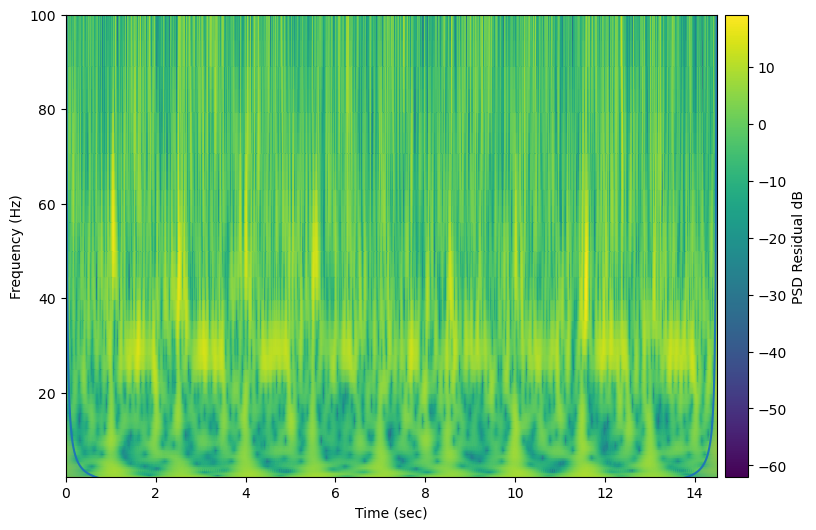